# Resistance & recovery 4-sp communities: Analyze OD data

1st author

# Introduction

This document goes along with `main_expt--flow_cytometry_analysis.Rmd`. So you will have to run the top part of that script first to produce the annotation file used below: “annotation_for_alldata.csv”.

The main purpose of this script is to wrangle the microspectrophotometer OD data for each day of the experiment. This data is used to identify wells that went extinct: these extinct wells are outputed to a file called “extinctOD_wells.csv” that is then used somewhere in the middle of `main_expt--flow_cytometry_analysis.Rmd`. Finally, the OD data is plotted (and some of the plots from here will make it into the supplement).

# Process the data

## Load the data

```r
library(tidyverse)
```

```r
library(RColorBrewer) # for changing the colours of plots
source("H1_extract_heatpulse_OD_data.R") # some functions to load the OD data from Gen5 .txt output format

# print the complete info about packages and versions currently loaded in the environment:
```

```r
# set theme for all plots
fave_theme <- theme_light() + # see other options at https://ggplot2.tidyverse.org/reference/ggtheme.html
              theme(text = element_text(size=15), # larger text size for titles & axes
                    panel.grid.major = element_blank(), # remove major gridlines
                    panel.grid.minor = element_blank()) # remove minor gridlines
theme_set(fave_theme)

# define a palette for plotting the 4 species
species_4pal = palette.colors(8, palette = "R4")[c(3, 5, 7, 2)] #in alphabetical order
# define a palette for plotting the inoculated community richness
CommRich_pal <- scale_colour_viridis_d(option = "viridis", begin=0.2, end=0.95)
# define a palette for plotting the heat duration
control_to_48h_pal <- scale_colour_viridis_d(option = "plasma", begin=0.05, end = 0.9)
```

Load the OD data from the .txt files exported from the Gen5 software. Add annotation by calling on a .csv file in the same folder as this script.

```r
# import the data
rawOD.data <- rbind(get_ODdata_serialbatch(folder="./raw_data/serial_transf--2July24/OD growth curves Epoch2", incubator="Epoch", heat=6, Date="24-07-02"),
                    get_ODdata_serialbatch(folder="./raw_data/serial_transf--8July24/OD growth curves Epoch2", incubator="Epoch", heat=0, Date="24-07-08"),
                    get_ODdata_serialbatch(folder="./raw_data/serial_transf--8July24/OD growth curves H1", incubator="H1", heat=48, Date="24-07-08"),
                    get_ODdata_serialbatch(folder="./raw_data/serial_transf--5Aug24/OD growth curves Epoch2", incubator="Epoch", heat=12, Date="24-08-05"),
                    get_ODdata_serialbatch(folder="./raw_data/serial_transf--19Aug24/OD growth curves Epoch2", incubator="Epoch", heat=24, Date="24-08-19")
                    )

# open the annotation file
annotation <- read.csv("./intermediate_data/annotation_for_alldata.csv")
# drop columns that pertain to flow cytometry (and then resultant redundant rows)
annotation <- annotation %>% select(-FLOWplateWell, -Plate) %>% distinct

# add annotation to the OD data
rawOD.data <- left_join(rawOD.data, annotation,
                        by=c("uniqID", "OD_well", "Date", "Day", "Incubator", "Heat"))

# on 24-07-08 and 24-08-19: I screwed up the inoculation of all wells in column 8. Ignore these wells altogether.
rawOD.data <- rawOD.data[-intersect(which(rawOD.data$Date == "24-07-08"), # match the date !!!AND!!!
                                    which(rawOD.data$OD_well %in% paste0(LETTERS[1:8],8))),] # match the column
rawOD.data <- rawOD.data[-intersect(which(rawOD.data$Date == "24-08-19"), # same as above but for different date
                                    which(rawOD.data$OD_well %in% paste0(LETTERS[1:8],8))),]

# Well A6 only on Day 1 of 24-07-02: no flow cytometry data bc of mistake. But there is OD data, currently lacking annotation.
# Add appropriate annotation to this well.
  # get the appropriate data for species, inoculated community richness, and the heat treatment
species.A6 <- rawOD.data %>% filter(uniqID == "24-07-02 Epoch A6", Day>1) %>% select(putida:CommRich) %>% distinct()
heat.A6 <- rawOD.data %>% filter(Date == "24-07-02", Day==1, CommRich>0) %>% select(Heat_Day:Recov_Day) %>% distinct()
annot.A6 <- cbind(species.A6, heat.A6)
  # add the annotation to the data
annot.A6 <- merge(rawOD.data %>% filter(uniqID == "24-07-02 Epoch A6", Day==1) %>% select(-(putida:Recov_Day)), annot.A6)
  # replace the incorrectly annotated data with the properly annotated one.
rawOD.data <- rbind(rawOD.data[-intersect(which(rawOD.data$uniqID=="24-07-02 Epoch A6"),which(rawOD.data$Day==1)),], # excludes incorrectly annotated data
                    annot.A6)

# clean-up
rm(species.A6, heat.A6, annot.A6, annotation)
```

## Baseline subtraction

Let’s make some preliminary plots of the data so we have an idea what we are dealing with…

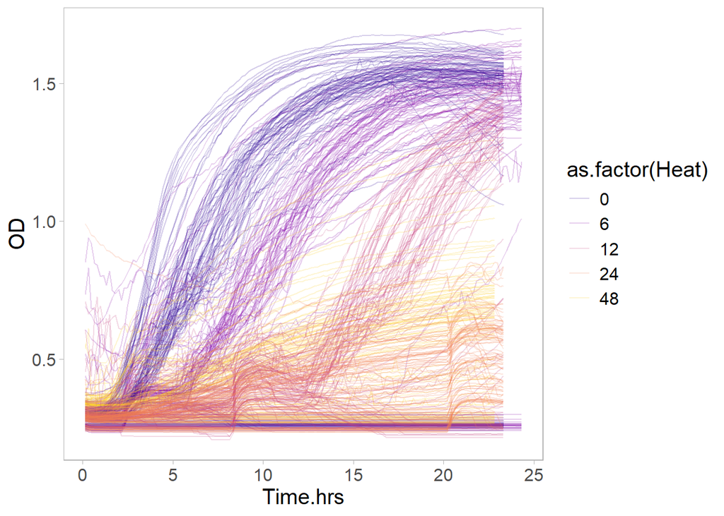

```r
# add a column to indicate which rows are coming from the same sample on the same day
rawOD.data <- rawOD.data %>% unite(uniqCurve, c(uniqID, Day), sep=" ", remove=FALSE)

# plot
ggplot(rawOD.data %>% filter(!is.na(CommRich), Day==2),
       aes(x=Time.hrs, y=OD, group=uniqCurve, colour=as.factor(Heat))) +
  geom_line(alpha=0.2) +
  control_to_48h_pal
```

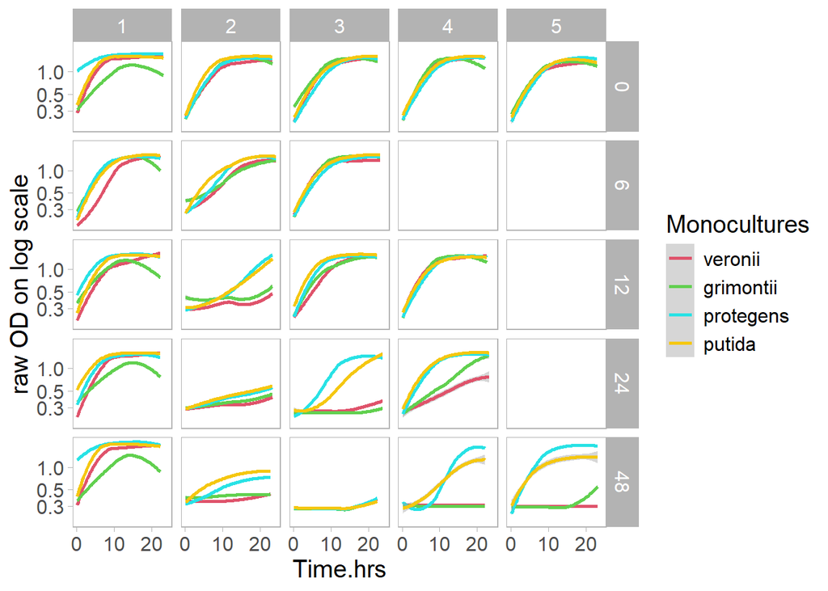

```r
ggplot(rawOD.data %>% filter(CommRich==1) %>% unite(community, putida:veronii),
       aes(x=Time.hrs, y=OD, group=uniqCurve, colour=community)) +
  facet_grid(rows=vars(Heat), cols=vars(Day)) +
  geom_smooth(aes(group=community)) +
  scale_y_log10() +
  scale_x_continuous(breaks=c(0,10,20)) +
  scale_colour_manual(values=species_4pal[c(4,1,2,3)],
                      labels=c("veronii", "grimontii", "protegens", "putida")) +
  labs(colour="Monocultures", y="raw OD on log scale")
```

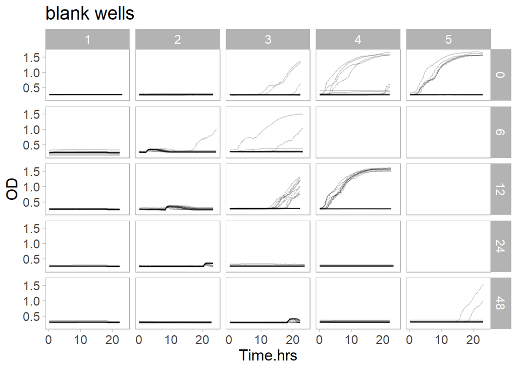

```r
ggplot(rawOD.data %>% filter(CommRich==0),
       aes(x=Time.hrs, y=OD, group=uniqCurve)) +
  facet_grid(rows=vars(Heat), cols=vars(Day)) +
  geom_line(alpha=0.2) +
  scale_x_continuous(breaks=c(0,10,20)) +
  labs(title = "blank wells")
```

Contamination is evident in the blank wells. But also, we can clearly see condensation when the temperature is reduced from 40C down to 30C. I will baseline subtract using the media value of the blank OD to try to remove this condensation artefact.

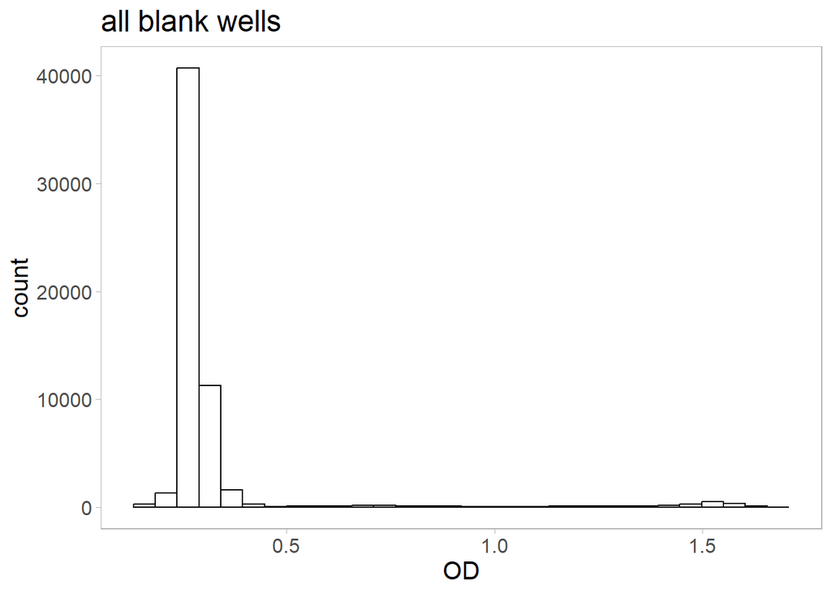

```r
# identify contaminated Wells to exclude them from the baseline
ggplot(rawOD.data %>% filter(CommRich==0), aes(x=OD)) +
  geom_histogram(colour="black", fill="white") +
  labs(title="all blank wells")
```

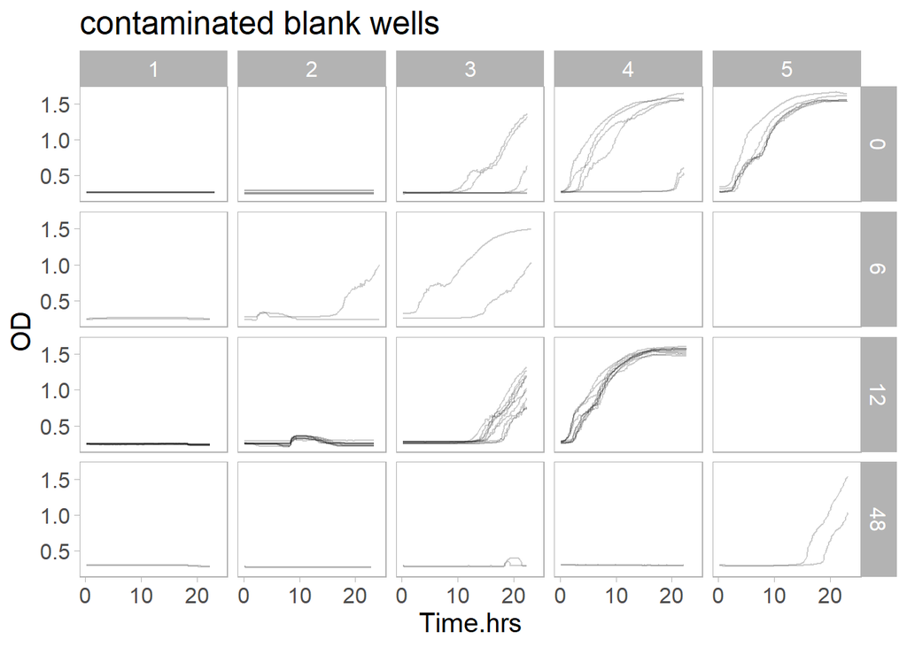

```r
# let's suppose that we consider any OD > 1 as indicative of growth
contaminated.blanks <- rawOD.data %>% filter(CommRich==0, OD > 1) %>% select(uniqID) %>% unlist()
contaminated.blanks <- rawOD.data %>% filter(uniqID %in% contaminated.blanks)
ggplot(contaminated.blanks,
       aes(x=Time.hrs, y=OD, group=uniqCurve)) +
  facet_grid(rows=vars(Heat), cols=vars(Day)) +
  geom_line(alpha=0.2) +
  scale_x_continuous(breaks=c(0,10,20)) +
  labs(title = "contaminated blank wells")
```

```r
# calculate baseline using blank time-points with OD < 1
tempOD <- rawOD.data[-intersect(which(rawOD.data$CommRich==0),which(rawOD.data$OD>1)),]
# get the median OD value for each time point
blanks.median <- tempOD %>% filter(CommRich==0) %>%
                    group_by(Date, Day, Incubator, Time.hrs) %>%
                        summarise(medianOD = median(OD))
```

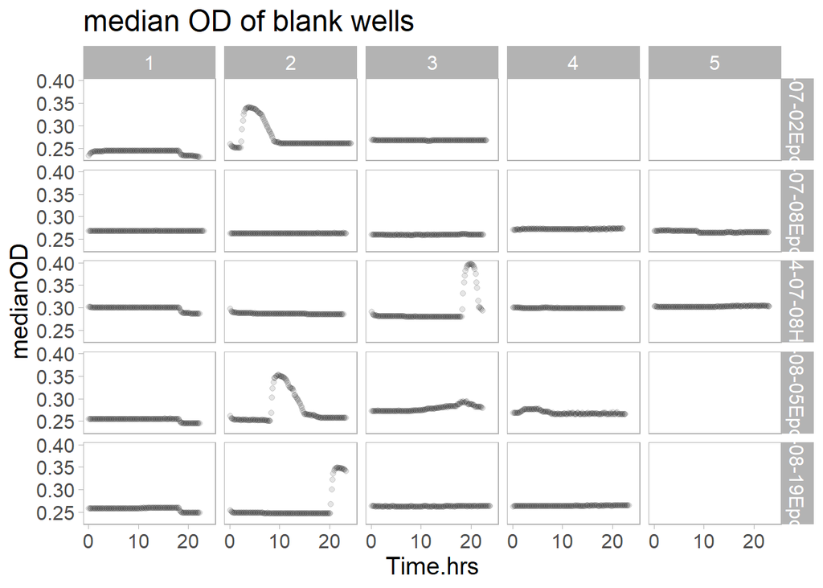

```r
# plot the values for sanity check:
ggplot(blanks.median,
       aes(x=Time.hrs, y=medianOD)) +
  facet_grid(rows=vars(paste0(Date, Incubator)), cols=vars(Day)) +
  geom_point(alpha=0.1) +
  scale_x_continuous(breaks=c(0,10,20)) +
  labs(title="median OD of blank wells")
```

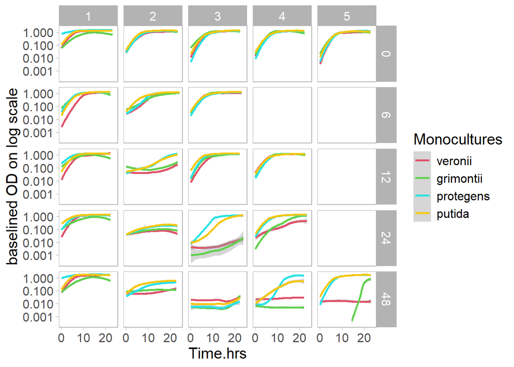

```r
# combine the median blank OD values back to the original data
the.data <- left_join(tempOD, blanks.median,
                    by=c("Date", "Day", "Incubator", "Time.hrs")) %>%
              mutate(baselinedOD = OD-medianOD)
# (do the same for the contaminated data. It will be useful later on.)
contaminated.blanks <- left_join(contaminated.blanks, blanks.median,
                                 by=c("Date", "Day", "Incubator", "Time.hrs")) %>%
                          mutate(baselinedOD = OD-medianOD)

# remove the contaminated blanks from the main data
the.data <- the.data[-which(the.data$uniqID %in% unique(contaminated.blanks$uniqID)),]

# re-do the monoculture plots from above to make sure the baselining of OD worked:
ggplot(the.data %>% filter(CommRich==1) %>% unite(community, putida:veronii),
       aes(x=Time.hrs, y=baselinedOD, group=uniqCurve, colour=community)) +
  facet_grid(rows=vars(Heat), cols=vars(Day)) +
  geom_smooth(aes(group=community)) +
  scale_y_log10() +
  scale_x_continuous(breaks=c(0,10,20)) +
  scale_colour_manual(values=species_4pal[c(4,1,2,3)],
                      labels=c("veronii", "grimontii", "protegens", "putida")) +
  labs(colour="Monocultures", y="baselined OD on log scale")
```

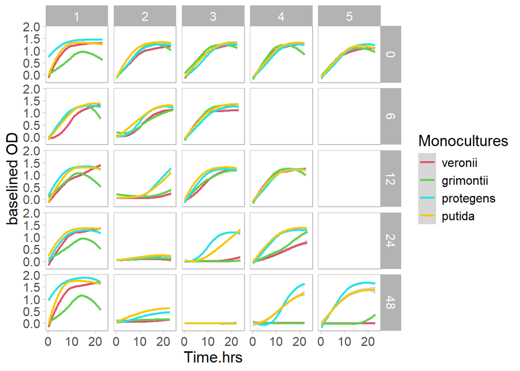

```r
ggplot(the.data %>% filter(CommRich==1) %>% unite(community, putida:veronii),
       aes(x=Time.hrs, y=baselinedOD, group=uniqCurve, colour=community)) +
  facet_grid(rows=vars(Heat), cols=vars(Day)) +
  geom_smooth(aes(group=community)) +
  scale_x_continuous(breaks=c(0,10,20)) +
  scale_colour_manual(values=species_4pal[c(4,1,2,3)],
                      labels=c("veronii", "grimontii", "protegens", "putida")) +
  labs(colour="Monocultures", y="baselined OD")
```

```r
rm(tempOD, blanks.median)
```

Everything looks as good as can be expected :)